# Inferential Data Analysis Practice

Jacky Pan

## Overview

The project is to analyze the ToothGrowth data in R datasets packages. The process includes:

1. Exploratory data analysis to summarize data.
2. Hypothesis statement after analysis to gain insight.
3. Hypothesis testing via confidence intervals or other testing methods.
4. Conclusion obtained from analysis.

## Exploratory analysis and hypothesis development

The data of ToothGrowth is a data fram with 60 observations on 3 variables.

[,1] len numeric Tooth length.

[,2] supp factor Supplement type (VC or OJ).

[,3] dose numeric Dose in milligrams/day.

```r
data("ToothGrowth")
dim(ToothGrowth)
```

```
## [1] 60  3
```

```r
names(ToothGrowth)
```

```
## [1] "len"  "supp" "dose"
```

```r
summary(ToothGrowth)
```

```
##       len        supp         dose
##  Min.   : 4.20   OJ:30   Min.   :0.500
##  1st Qu.:13.07   VC:30   1st Qu.:0.500
##  Median :19.25           Median :1.000
##  Mean   :18.81           Mean   :1.167
##  3rd Qu.:25.27           3rd Qu.:2.000
##  Max.   :33.90           Max.   :2.000
```

After depicting a boxplot, we found that the supplement type of orange juice (OJ) has greater mean and less variance compared to the supplement type of ascorbic acid (VC).

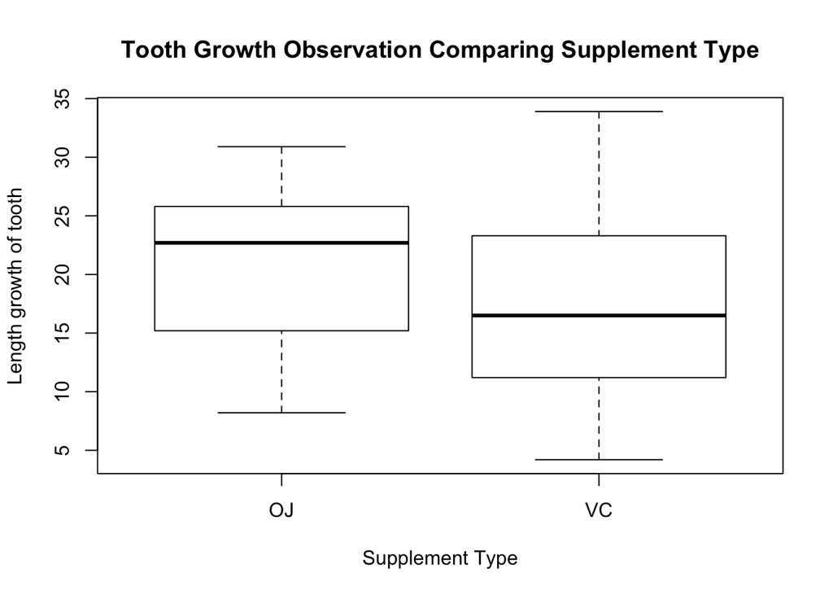

```r
boxplot(len ~ supp, data = ToothGrowth, xlab = "Supplement Type", ylab = "Length growth of tooth", main = "Tooth Growth Observation Comparing Supplement Type")
```

We depicted another boxplot and found that the greater dose levels of vitamin C, the longer the tooth growth.

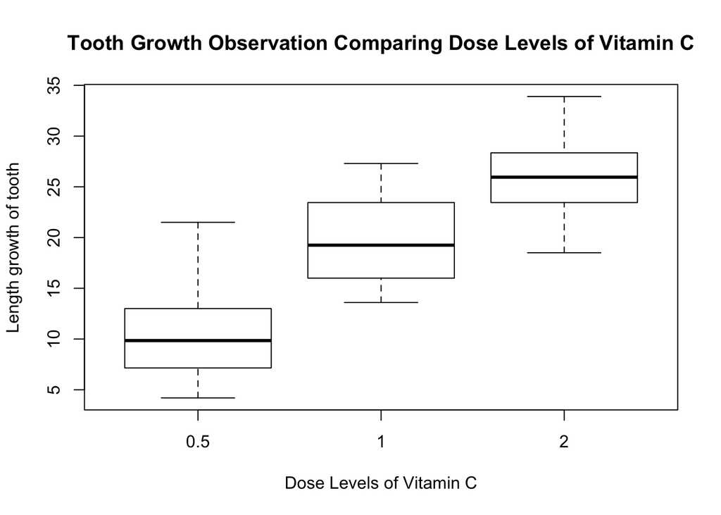

```r
boxplot(len ~ dose, data = ToothGrowth, xlab = "Dose Levels of Vitamin C", ylab = "Length growth of tooth", main = "Tooth Growth Observation Comparing Dose Levels of Vitamin C")
```

**Based on the data exploration, we develop two hypotheses for our data:**

- H1. The supplement type of orange juice (OJ) has stronger influence on length of tooth growth than the supplement type of ascorbic acid (VC)
- H2. The dose levels of vitamin C is positively associated with length of tooth growth.

## Hypothesis testing

### H1.

We perform t-test to determine whether the two supplement type are significantly different, which means the rejection of null hypothesis (the supplement type has the same effect on tooth growth).

The result indicates that we don’t reject the null hypothesis because p-value is larger than 0.05 and the mean difference lies in confidence interval. **H1 is not supported.**

```r
t.test(len ~ supp, var.equal = F, paired = F, data = ToothGrowth)
```

```
##
##  Welch Two Sample t-test
##
## data:  len by supp
## t = 1.9153, df = 55.309, p-value = 0.06063
## alternative hypothesis: true difference in means is not equal to 0
## 95 percent confidence interval:
##  -0.1710156  7.5710156
## sample estimates:
## mean in group OJ mean in group VC
##         20.66333         16.96333
```

### H2.

The number of class of dose levels is three so we can’t apply t-test. Instead, we perform one-way anova to test our hypothesis.

The result shows that F value is 105.1 and p-value is smaller that 0.05. We can reject the null hypothesis(The influence of dose levels are the same.). **H2 is supported**

```r
summary(aov(len ~ dose, data = ToothGrowth))
```

```
##             Df Sum Sq Mean Sq F value   Pr(>F)
## dose         1   2224  2224.3   105.1 1.23e-14 ***
## Residuals   58   1228    21.2
## ---
## Signif. codes:  0 '***' 0.001 '**' 0.01 '*' 0.05 '.' 0.1 ' ' 1
```

## Conclusion

> 1. The supplement type (OJ & VC) has no difference on tooth growth.
> 2. The more dose levels of vitamin C, the greater influence on tooth growth.